# notebook

**Note**

Following features are added in the analysis of dataset below

# Table of Contents:

- 1) Problem statement
- 2) Importing requried Libraries
- 3) Pre-process data
  - 3.1) Selecting Only Required features from dataset
  - 3.2) Checking missing values
  - 3.3) Converting float values to integer from indexed features
- 4) Analysis on intial features:
  - 4.4) Checking the correlation of given features with the O:E
  - 4.5) Checking the correlation of given features with the hour of discharge
  - 4.6) Selecting Top corelated Features for O:E
  - 4.7) Selecting Top corelated Features for hour of discharge
  - 4.8) **Impact O:E and hour and discharge by discharge on weekend feature**
  - 4.9) **Impact O:E and hour and discharge by Floor_of_hospital_index feature**
  - 4.10)**Impact O:E and hour and discharge by DC_location_index' feature**
- 5) Analysis of Clinical features
  - 5.1) **Impact of Avg_DBP on O:E and Hour of discharge**
  - 5.2) **Impact of Avg_SBP on O:E and Hour of discharge**
- 6) Analysis of Communication features
  - 6.1) **Impact of sent messages and read meassges per day on O:E**
  - 6.2) **Impact of sent messages and read meassges per day on Hour of discharge**
- 7) Analysis of Network Metrics
  - 7.1) Convert Raw data into Graph dataset
  - 7.2) Basic details of the network
  - 7.3) Basic visualization of the network
  - 7.4) List of top connected patient Ids in the data
  - 7.5) **Impact of Gorups Group Visualizations**
- 8) Analysis of Centrality Metrics
  - 8.1) **Impact of medicine attenging indegree**
  - 8.2) **Impact of medicine attenging outdegree**
  - 8.3) **Impact of Nurse Indegree and Outdegree**

# 1) Problem statement

Your given goal and problem statement for the analysis of your given dataset

- Goal: - To understand the distribution (including summary statistics and whether they are normally distributed) and inter-relatedness of, in particular, the group-level and individual-level social network analysis metrics. - Continue with above with the messaging frequency metrics. - Feature engineering (10 features with 5 using network columns).
- Background: The project is related to determining whether the other columns have a impact on the target variables O:E and hour_of_discharge (Observed to expected length of stay in the hospital)

# 2) Importing required libraries

```python
import pandas as pd
import networkx as nx
import matplotlib.pyplot as plt
import seaborn as sns
import numpy as np
```

```python
data = pd.read_csv("data(1).csv")
data.head()
```

|  | Unnamed: 0 | patient_index | Encounter_index | O:E | hour_of_discharge | Diagnosis_index | Floor_of_hospital_index | hospital_index | Ward_Specialty_index | admission_on_weekend | ... | SW,CM,AHP_indegree | SW,CM,AHP_outdegree | SW,CM,AHP_closeness | SW,CM,AHP_betweeness | SW,CM,AHP_Klein_authority | SW,CM,AHP_Klein_hub | SW,CM,AHP_coreness | SW,CM,AHP_eccentricity | SW,CM,AHP_harmonic_centrality | SW,CM,AHP_transitivity_local |
| --- | --- | --- | --- | --- | --- | --- | --- | --- | --- | --- | --- | --- | --- | --- | --- | --- | --- | --- | --- | --- | --- |
| 0 | 2465.049364 | 1514.294232 | -27.512001 | 1.053083 | 13.051697 | 165.072781 | 19.204117 | 1.010370 | 1.964990 | 0.001279 | ... | 6.856729 | 6.818404 | 0.448873 | 241.260474 | 0.462310 | 0.437710 | 4.962749 | 4.876502 | 0.519597 | 0.524947 |
| 1 | 1307.598166 | 673.566845 | 3.434191 | 2.722624 | 18.843248 | 327.504165 | 20.779564 | 1.011251 | 2.033301 | 1.009949 | ... | 8.059154 | 17.487387 | 0.941862 | -1.689837 | 0.885362 | 0.970651 | 15.075927 | 2.079791 | 0.968420 | 0.708207 |
| 2 | 932.924722 | 958.722669 | -13.718790 | 2.807767 | 13.812463 | 330.786123 | 8.969102 | 0.012797 | 1.985404 | -0.006888 | ... | 7.667162 | 15.354715 | 0.951904 | 5.227171 | 0.879858 | 0.995629 | 13.882536 | 1.784665 | 0.858040 | 0.690157 |
| 3 | -183.118923 | 2133.785877 | 0.070659 | 3.501456 | 10.839802 | 296.355969 | 6.168706 | -0.017919 | 2.056591 | 0.018736 | ... | 4.950450 | 7.033584 | 0.532028 | 64.349696 | 0.571991 | 0.558398 | 7.406528 | 3.962442 | 0.637591 | 0.183622 |
| 4 | 1145.841011 | 1601.247421 | -16.048156 | 2.763380 | 11.217067 | 12.142270 | 14.619572 | 0.988466 | 1.972843 | -0.006215 | ... | 5.706627 | 7.991794 | 0.657433 | 31.447479 | 0.731886 | 0.389146 | 5.693688 | 1.685407 | 0.723111 | 0.575370 |

5 rows × 140 columns

# 3) Pre-process Data

### 3.1) Selecting only required features from the dataset

There Are three kinds of analysis the we are going to incorporate in this analysis to answer the goal of our problem defination.

- First we will use the given features above in .rtf file to check the effect of features on O:E and hour of discharge.
  - Select these features from the dataset
  - Checking for any missing or null values
  - Explore the relationship of these features with "O:E" and "hour_of_discharge" variables.
- Secondly, We will check answers related to communication metrics what impact does communication metrics have on the O:E and hour of discharge.
  - we will use sent_msgs_per_day and read_msgs_per_day
- Thirdly, We are going to create the network of patients
  - compute the size of network
    - number of nodes, number of edges
    - density
    - Average degree
    - Clustering coefficient
- Finally we will compute the centrality measures in our network to find
  - Indegree measures of the network
  - Outdegree mesures of the network

```python
required_features = ["patient_index", "Encounter_index","O:E",  "hour_of_discharge",
                    "Diagnosis_index", "Floor_of_hospital_index", "hospital_index",
                    "Ward_Specialty_index", "admission_on_weekend", "discharge_on_weekend",
                    "resident_majority", "app_majority", "Insurance_index", "Admit_location_index",
                    "DC_location_index"]
```

```python
problem1_data = data[required_features]
problem1_data.head()
```

|  | patient_index | Encounter_index | O:E | hour_of_discharge | Diagnosis_index | Floor_of_hospital_index | hospital_index | Ward_Specialty_index | admission_on_weekend | discharge_on_weekend | resident_majority | app_majority | Insurance_index | Admit_location_index | DC_location_index |
| --- | --- | --- | --- | --- | --- | --- | --- | --- | --- | --- | --- | --- | --- | --- | --- |
| 0 | 1514.294232 | -27.512001 | 1.053083 | 13.051697 | 165.072781 | 19.204117 | 1.010370 | 1.964990 | 0.001279 | 0.979957 | 0.994454 | 0.020637 | 2.100997 | 2.067558 | 6.127387 |
| 1 | 673.566845 | 3.434191 | 2.722624 | 18.843248 | 327.504165 | 20.779564 | 1.011251 | 2.033301 | 1.009949 | -0.005257 | 0.006252 | 0.990356 | 4.056156 | 1.931223 | 8.890666 |
| 2 | 958.722669 | -13.718790 | 2.807767 | 13.812463 | 330.786123 | 8.969102 | 0.012797 | 1.985404 | -0.006888 | 0.036913 | 0.019310 | 0.970940 | 1.997155 | 2.047063 | 5.909845 |
| 3 | 2133.785877 | 0.070659 | 3.501456 | 10.839802 | 296.355969 | 6.168706 | -0.017919 | 2.056591 | 0.018736 | -0.020165 | 0.010783 | -0.049982 | 1.995565 | 2.022593 | 5.892701 |
| 4 | 1601.247421 | -16.048156 | 2.763380 | 11.217067 | 12.142270 | 14.619572 | 0.988466 | 1.972843 | -0.006215 | -0.002693 | 1.007540 | -0.000909 | 4.068544 | 1.965491 | 15.109740 |

### 3.2) Checking if there is any missing values in the features

```python
problem1_data.isna().sum()
```

```
patient_index              0
Encounter_index            0
O:E                        0
hour_of_discharge          0
Diagnosis_index            0
Floor_of_hospital_index    0
hospital_index             0
Ward_Specialty_index       0
admission_on_weekend       0
discharge_on_weekend       0
resident_majority          0
app_majority               0
Insurance_index            0
Admit_location_index       0
DC_location_index          0
dtype: int64
```

### 3.3) Float values in index

In the above given features we have observed that index values in columns got float values but the unique indexes features should be int values that why we are going to conver the float values into the int type.

```python
problem1_data = problem1_data[required_features].astype(int)
problem1_data.head()
```

|  | patient_index | Encounter_index | O:E | hour_of_discharge | Diagnosis_index | Floor_of_hospital_index | hospital_index | Ward_Specialty_index | admission_on_weekend | discharge_on_weekend | resident_majority | app_majority | Insurance_index | Admit_location_index | DC_location_index |
| --- | --- | --- | --- | --- | --- | --- | --- | --- | --- | --- | --- | --- | --- | --- | --- |
| 0 | 1514 | -27 | 1 | 13 | 165 | 19 | 1 | 1 | 0 | 0 | 0 | 0 | 2 | 2 | 6 |
| 1 | 673 | 3 | 2 | 18 | 327 | 20 | 1 | 2 | 1 | 0 | 0 | 0 | 4 | 1 | 8 |
| 2 | 958 | -13 | 2 | 13 | 330 | 8 | 0 | 1 | 0 | 0 | 0 | 0 | 1 | 2 | 5 |
| 3 | 2133 | 0 | 3 | 10 | 296 | 6 | 0 | 2 | 0 | 0 | 0 | 0 | 1 | 2 | 5 |
| 4 | 1601 | -16 | 2 | 11 | 12 | 14 | 0 | 1 | 0 | 0 | 1 | 0 | 4 | 1 | 15 |

# 4) Analysis on intial features

### 4.1) 4.2) Checking the correlation of given features with the O:E and Hour of discharge feature.

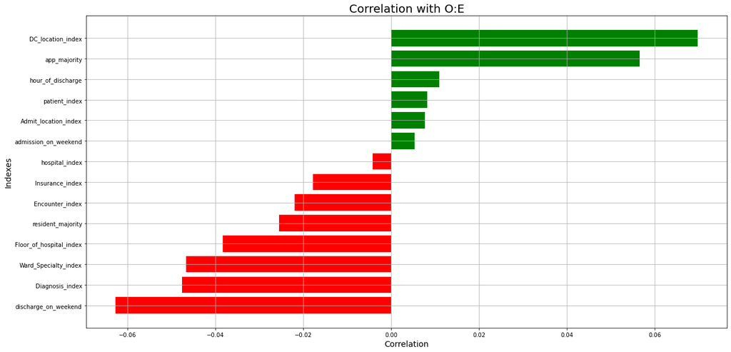

```python
corr_matrix = problem1_data.corr()
CPI_corr = corr_matrix['O:E'].sort_values()
CPI_corr.head()

filter = np.abs(CPI_corr)>=0.6
#CPI_corr[filter].plot.barh(figsize=(20,10), grid=True)
filtered_corr = CPI_corr[filter]

colors = []

for val in CPI_corr:
    if val < 0 :
        colors.append('red')
    else:
        colors.append('green')

plt.figure(figsize=(20, 10))
plt.barh(CPI_corr.index[:-1], CPI_corr[:-1], color=colors)
plt.title("Correlation with O:E", size=20)
plt.xlabel("Correlation", size=14)
plt.ylabel("Indexes", size=14)
plt.grid(True)
plt.show()
```

### explainations:

While the data doesn't reveal substantial correlations between the features and O:E values, there are noteworthy observations. Notably, the location index demonstrates stronger positive correlations with O:E compared to other variables. On the other hand, discharges occurring on weekends display a more pronounced negative correlation with O:E.

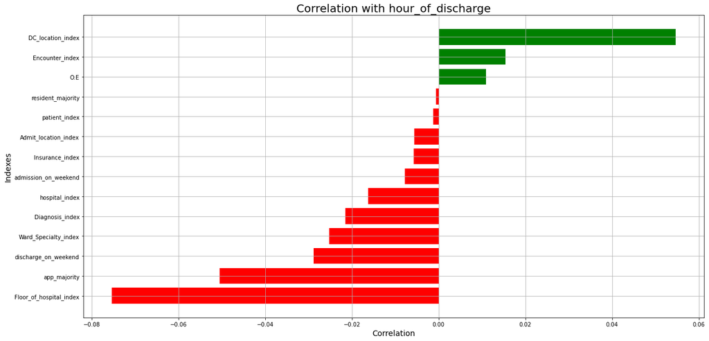

```python
corr_matrix = problem1_data.corr()
CPI_corr = corr_matrix['hour_of_discharge'].sort_values()
CPI_corr.head()

filter = np.abs(CPI_corr)>=0.6
#CPI_corr[filter].plot.barh(figsize=(20,10), grid=True)
filtered_corr = CPI_corr[filter]

colors = []

for val in CPI_corr:
    if val < 0 :
        colors.append('red')
    else:
        colors.append('green')

plt.figure(figsize=(20, 10))
plt.barh(CPI_corr.index[:-1], CPI_corr[:-1], color=colors)
plt.title("Correlation with hour_of_discharge", size=20)
plt.xlabel("Correlation", size=14)
plt.ylabel("Indexes", size=14)
plt.grid(True)
plt.show()
```

### 4.3) Top corelated Features for Hour of discharge

```python
corr_matrix = problem1_data.corr()
corr = corr_matrix['hour_of_discharge'].sort_values()


filter = np.abs(corr)>0.06
filtered_corr = corr[filter]
top=list(filtered_corr.index)[:-1]
top
```

```
['Floor_of_hospital_index']
```

### 4.4) Top corelated Features for O:E

```python
corr_matrix = problem1_data.corr()
CPI_corr = corr_matrix['O:E'].sort_values()
CPI_corr.head()

filter = np.abs(CPI_corr)>0.06
filtered_corr = CPI_corr[filter]
top=list(filtered_corr.index)[:-1]
top
```

```
['discharge_on_weekend', 'DC_location_index']
```

### 4.5) Selecting top correlated feature for both dependant variables

- Hour of discharge
  - 'Floor_of_hospital_index',
- O:E
  - 'discharge_on_weekend',
  - 'DC_location_index',

### 4.6) Impact O:E and hour and discharge by discharge on weekend feature

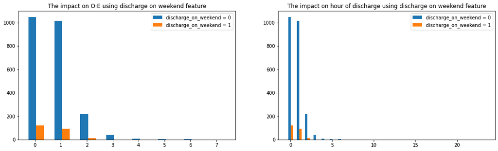

```python
from collections import Counter
### Checking The impact of above features on the O:E


def get_lists(oe):

    ls1, ls2 = list(),list()
    for val in oe:
        dat = problem1_data[problem1_data["O:E"] == val]["discharge_on_weekend"]
        dict_Data = dict(Counter(dat))


        if(len(dict_Data)>1):
            ls1.append(dict_Data[0])
            ls2.append(dict_Data[1])
        elif(len(dict_Data) == 1):
            ls1.append(dict_Data[0])
            ls2.append(0)
        else:
            ls1.append(0)
            ls2.append(0)

    return ls1, ls2



oe = set(problem1_data["O:E"])
ls1, ls2 = get_lists(oe)

fig, ax = plt.subplots(1,2 , figsize = (18,5))

ax[0].bar([val-0.1 for val in oe], ls1, width=0.3, label = "discharge_on_weekend = 0")
ax[0].bar([val+0.2 for val in oe], ls2, width=0.3, label = "discharge_on_weekend = 1")
ax[0].set_title("The impact on O:E using discharge on weekend feature")
ax[0].legend()


oe = set(problem1_data["hour_of_discharge"])
ls1, ls2 = get_lists(oe)

ax[1].bar([val-0.1 for val in oe], ls1, width=0.3, label = "discharge_on_weekend = 0")
ax[1].bar([val+0.2 for val in oe], ls2, width=0.3, label = "discharge_on_weekend = 1")
ax[1].set_title("The impact on hour of discharge using discharge on weekend feature")
ax[1].legend()

plt.show()
```

### 4.7) Impact O:E and hour and discharge by Floor_of_hospital_index feature

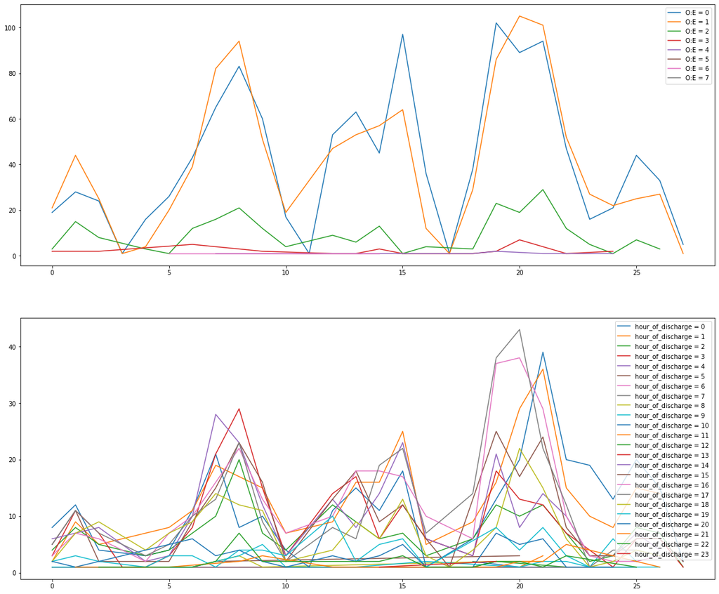

```python
fig,ax = plt.subplots(2,1, figsize=(20, 17))
oe = set(problem1_data["O:E"])

for val in oe:
    filterd =problem1_data[problem1_data["O:E"] == val]
    group =filterd.groupby("Floor_of_hospital_index")["O:E"].count()
    ax[0].plot(group, label = f"O:E = {val}" )

ax[0].legend()

hod = set(problem1_data["hour_of_discharge"])
for val in hod:
    filterd =problem1_data[problem1_data["hour_of_discharge"] == val]
    group =filterd.groupby("Floor_of_hospital_index")["O:E"].count()
    ax[1].plot(group, label = f"hour_of_discharge = {val}" )

ax[1].legend()
plt.show()
```

#### Explainations:

There are three specific floors where we observe significant spikes in both O:E (Observed-to-Expected) and hour of discharge values. These spikes are particularly noticeable in our line plots, indicating notable variations in these two variables. The floors that exert a substantial impact on both O:E and hour of discharge values are the ones within the range of 5 to 10, 10 to 15, and a peak at the 20th floor, which exhibits the highest impact among them.

### 4.8 ) Impact O:E and hour and discharge by DC_location_index' feature

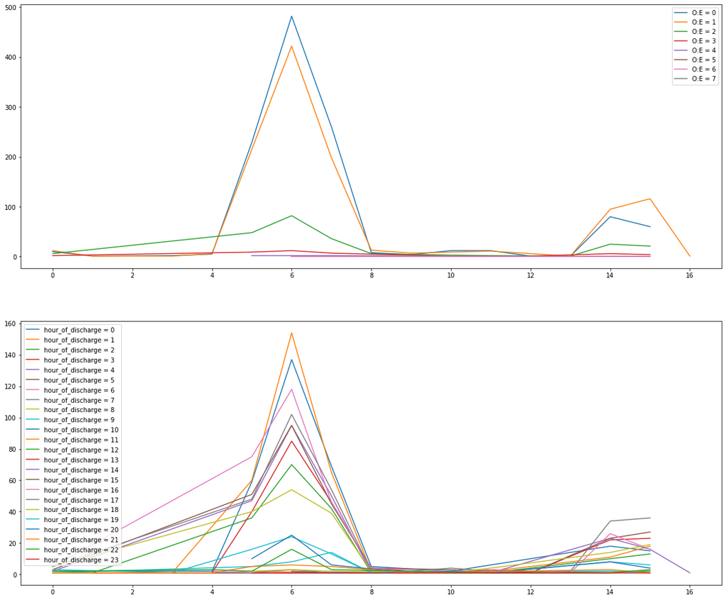

```python
fig,ax = plt.subplots(2,1, figsize=(20, 17))
oe = set(problem1_data["O:E"])

for val in oe:
    filterd =problem1_data[problem1_data["O:E"] == val]
    group =filterd.groupby("DC_location_index")["O:E"].count()
    ax[0].plot(group, label = f"O:E = {val}" )

ax[0].legend()

hod = set(problem1_data["hour_of_discharge"])
for val in hod:
    filterd =problem1_data[problem1_data["hour_of_discharge"] == val]
    group =filterd.groupby("DC_location_index")["O:E"].count()
    ax[1].plot(group, label = f"hour_of_discharge = {val}" )

ax[1].legend()
plt.show()
```

#### explainations:

# 5) Clinical Measurements:

- 1y_admissions: Hospital admissions count in the past year.
- 30d_admissions: Hospital admissions count in the last month.
- avg_sbp: Mean systolic blood pressure during the stay.
- avg_dbp: Mean diastolic blood pressure during the stay.

```python
required_feats = ["patient_index","1y_admissions", "30d_admissions","avg_sbp" , "avg_dbp",
                 "O:E",  "hour_of_discharge"]

clinical_measure_data = data[required_feats]
```

```python
clinical_measure_data.isna().sum()
```

```
patient_index        0
1y_admissions        0
30d_admissions       0
avg_sbp              0
avg_dbp              0
O:E                  0
hour_of_discharge    0
dtype: int64
```

```python
clinical_measure_data.loc[:,"O:E"] = clinical_measure_data["O:E"].astype(int)
clinical_measure_data.loc[:,"hour_of_discharge"] = clinical_measure_data["hour_of_discharge"].astype(int)
clinical_measure_data.loc[:,"patient_index"] = clinical_measure_data["patient_index"].astype(int)

clinical_measure_data = clinical_measure_data.sort_values(by="patient_index")
clinical_measure_data.head()
```

|  | patient_index | 1y_admissions | 30d_admissions | avg_sbp | avg_dbp | O:E | hour_of_discharge |
| --- | --- | --- | --- | --- | --- | --- | --- |
| 1203 | -61.0 | -0.125979 | 0.047439 | 128.486745 | 72.859117 | 0.0 | 16.0 |
| 1142 | -50.0 | -0.037783 | 0.014048 | 136.748590 | 77.716411 | 0.0 | 10.0 |
| 1230 | -30.0 | -0.032582 | 0.018836 | 117.349881 | 76.374364 | 0.0 | 12.0 |
| 1193 | -23.0 | -0.151281 | 0.021981 | 125.410459 | 78.934822 | 1.0 | 15.0 |
| 637 | -22.0 | 0.035825 | -0.008900 | 145.948112 | 66.008842 | 0.0 | 10.0 |

```python
fig, ax = plt.subplots(1,2, figsize = (18,5))

#checking what happend to O:E for different patients for there 1 year admissions and 30 days admissions
ax[0].plot(list(clinical_measure_data.patient_index), list(clinical_measure_data["1y_admissions"]), label = "1 Year admissions")
ax[0].plot(list(clinical_measure_data.patient_index), list(clinical_measure_data["30d_admissions"]), label = "30 days admissions")
ax[0].plot(list(clinical_measure_data.patient_index), list(clinical_measure_data["O:E"]), label = "O:E")
ax[0].legend()
ax[0].set_title("1 Year admissions affect on O:E")
ax[0].set_xlabel("Patient Index")
ax[0].set_ylabel("frequency")

#checking what happend to O:E for different patients for there 30 days admissions
ax[1].plot(list(clinical_measure_data.patient_index), list(clinical_measure_data["1y_admissions"]), label = "1 Year admissions")
ax[1].plot(list(clinical_measure_data.patient_index), list(clinical_measure_data["30d_admissions"]), label = "30 days admissions")
ax[1].plot(list(clinical_measure_data.patient_index), list(clinical_measure_data["hour_of_discharge"]), label = "hour_of_discharge")
ax[1].legend()
ax[1].set_title("1 Year admissions affect on hour_of_discharge")
ax[1].set_xlabel("Patient Index")
ax[1].set_ylabel("frequency")

plt.show()
```

[output not shown]

#### Other clinical measure feature analysis:

we will compare the other two feature with our dependant variables using box plots to see what kind of impact the average dbp and average sbp are putting on our dependant variable.

### 5.1) Impact of Avg_DBP on O:E and Hour of discharge

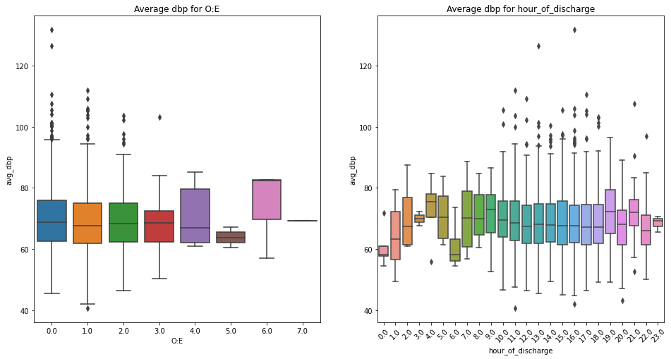

```python
fig, ax = plt.subplots(1,2, figsize = (16,8))
sns.boxplot(x="O:E", y="avg_dbp", data=clinical_measure_data,ax=ax[0])
ax[0].set_title("Average dbp for O:E")
sns.boxplot(x="hour_of_discharge", y="avg_dbp", data=clinical_measure_data,ax=ax[1])
ax[1].set_title("Average dbp for hour_of_discharge")
ax[1].set_xticklabels(ax[1].get_xticklabels(), rotation=45)
plt.show()
```

### Explainations:

In the box plots shown above, it's clear that we can evaluate the influence of mean diastolic blood pressure (DBP) during a patient's stay on different O:E (Observed-to-Expected) values.

### 5.2) Impact of Avg_SBP on O:E and Hour of discharge

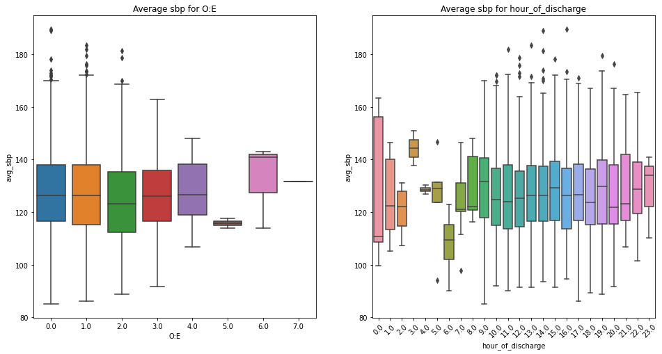

```python
fig, ax = plt.subplots(1,2, figsize = (16,8))
sns.boxplot(x="O:E", y="avg_sbp", data=clinical_measure_data,ax=ax[0])
ax[0].set_title("Average sbp for O:E")
sns.boxplot(x="hour_of_discharge", y="avg_sbp", data=clinical_measure_data,ax=ax[1])
ax[1].set_title("Average sbp for hour_of_discharge")
ax[1].set_xticklabels(ax[1].get_xticklabels(), rotation=45)
plt.show()
```

#### Explainations:

# 6) Communication Metrics:

- sent_msgs_per_day: Daily average of secure messages sent during hospitalization.
- read_msgs_per_day: Average daily messages others received during hospitalization.

```python
required_feats = ["patient_index","sent_msgs_per_day", "read_msgs_per_day",
                 "O:E",  "hour_of_discharge"]


communication_data = data[required_feats]
communication_data.loc[:,"O:E"] = communication_data["O:E"].astype(int)
communication_data.loc[:,"hour_of_discharge"] = communication_data["hour_of_discharge"].astype(int)
communication_data.loc[:,"read_msgs_per_day"] = communication_data["read_msgs_per_day"].astype(int)
communication_data.loc[:,"sent_msgs_per_day"] = communication_data["sent_msgs_per_day"].astype(int)
communication_data.head()
```

|  | patient_index | sent_msgs_per_day | read_msgs_per_day | O:E | hour_of_discharge |
| --- | --- | --- | --- | --- | --- |
| 0 | 1514.294232 | 54.0 | 97.0 | 1.0 | 13.0 |
| 1 | 673.566845 | 54.0 | 732.0 | 2.0 | 18.0 |
| 2 | 958.722669 | 40.0 | 496.0 | 2.0 | 13.0 |
| 3 | 2133.785877 | 33.0 | 120.0 | 3.0 | 10.0 |
| 4 | 1601.247421 | 21.0 | 81.0 | 2.0 | 11.0 |

### 6.1) Impact of sent messages and read meassges per day for O:E

### 6.2) Impact of sent messages and read meassges per day for Hour of discharge

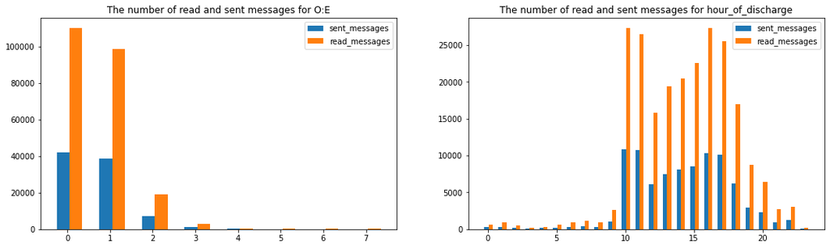

```python
fig, ax = plt.subplots(1,2 , figsize = (18,5))

def get_lists(var,dat):
    ls = []
    ls2 = []

    for val in dat:
        counter =communication_data[communication_data[var] == val]
        ls.append(sum(counter.sent_msgs_per_day))
        ls2.append(sum(counter.read_msgs_per_day))

    return ls, ls2


dat = set(communication_data["O:E"])
ls , ls2 = get_lists("O:E",dat)

ax[0].bar([val-0.1 for val in dat], ls, width=0.3, label = "sent_messages")
ax[0].bar([val+0.2 for val in dat], ls2, width=0.3, label = "read_messages")
ax[0].set_title("The number of read and sent messages for O:E")
ax[0].legend()


dat = set(communication_data["hour_of_discharge"])
ls , ls2 = get_lists("hour_of_discharge", dat)


ax[1].bar([val-0.1 for val in dat], ls, width=0.3, label = "sent_messages")
ax[1].bar([val+0.2 for val in dat], ls2, width=0.3, label = "read_messages")
ax[1].set_title("The number of read and sent messages for hour_of_discharge")
ax[1].legend()


plt.show()
```

### explainations:

Based on the visualizations presented above, there is a notable imbalance in the number of received messages compared to the sent messages of O:E when O:E is less than 2. A similar pattern emerges in the context of hour of discharge, but with a difference: when the hour of discharge value exceeds 10, there is an observable increase in the volume of communication metrics.

# 7 Network Metrics:

- size: Total count of individuals in the communication network.
- nedges: Total connections or "edges" among people in the network.
- density: Fraction of potential connections realized in the network.

```python
required_feats = ["patient_index","Encounter_index","size", "nedges","density",
                 "O:E",  "hour_of_discharge"]

Network_data = data[required_feats]
Network_data.isna().sum()
```

```
patient_index        0
Encounter_index      0
size                 0
nedges               0
density              0
O:E                  0
hour_of_discharge    0
dtype: int64
```

```python
Network_data.loc[:,"hour_of_discharge"] = Network_data["hour_of_discharge"].astype(int)
Network_data.loc[:,"O:E"] = Network_data["O:E"].astype(int)
Network_data.loc[:,"nedges"] = Network_data["nedges"].astype(int)
Network_data.loc[:,"size"] = Network_data["size"].astype(int)
Network_data.loc[:,"Encounter_index"] = Network_data["Encounter_index"].astype(int)
Network_data.loc[:,"patient_index"] = Network_data["patient_index"].astype(int)


Network_data.head()
```

|  | patient_index | Encounter_index | size | nedges | density | O:E | hour_of_discharge |
| --- | --- | --- | --- | --- | --- | --- | --- |
| 0 | 1514.0 | -27.0 | 45.0 | 157.0 | 0.078396 | 1.0 | 13.0 |
| 1 | 673.0 | 3.0 | 19.0 | 157.0 | 0.419803 | 2.0 | 18.0 |
| 2 | 958.0 | -13.0 | 18.0 | 120.0 | 0.358556 | 2.0 | 13.0 |
| 3 | 2133.0 | 0.0 | 17.0 | 81.0 | 0.231912 | 3.0 | 10.0 |
| 4 | 1601.0 | -16.0 | 25.0 | 86.0 | 0.157259 | 2.0 | 11.0 |

### 7.1) Converting The raw network data into Graph representations:

For creating the network from raw data we will use encounter index and patient index feature from the dataset.

```python
### Making bipartite network:

G = nx.Graph()
for i in range(len(Network_data)):

    node1 = Network_data.patient_index[i]
    node2 = Network_data.Encounter_index[i]

    if(G.has_edge(node1, node2)):
        continue
    else:
        if(node1 == node2):
            continue
        G.add_edge(node1, node2)
```

### 7.2) Basic network Information

The created network has following feature in it now.

```python
print("The number of nodes in the network are : ", len(G.nodes()))
print("The number of edges in the network are : ", len(G.edges()))


print("\nThe density of the network is :", round(nx.density(G) ,4))
print("Clustering Coefficient of the network is :", round(nx.average_clustering(G), 4))
```

```
The number of nodes in the network are :  2183
The number of edges in the network are :  2557

The density of the network is : 0.0011
Clustering Coefficient of the network is : 0.0008
```

```python
components = list(nx.connected_components(G))
largest_component = max(components, key=len)

lcs = G.subgraph(largest_component)
```

### 7.3) Basic network visualization

```python
pos = nx.kamada_kawai_layout(lcs)
```

```python
deg = [deg*2 for deg in dict(lcs.degree()).values()]
```

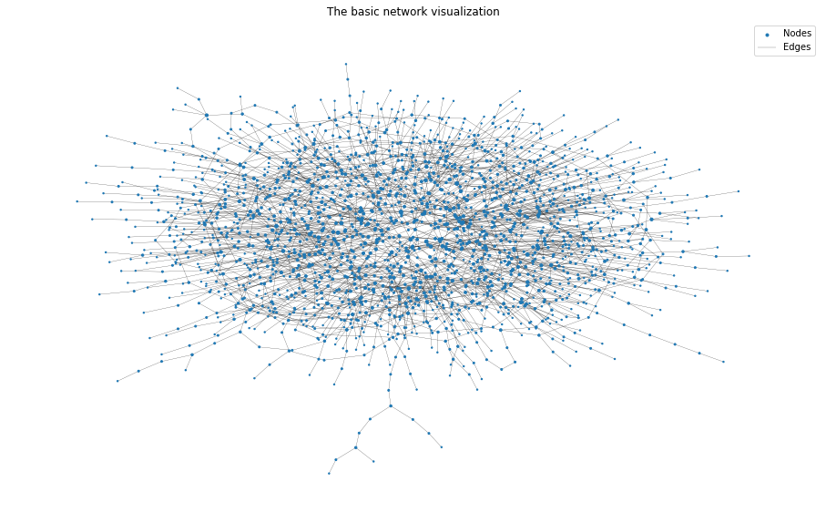

```python
fig = plt.figure(figsize=(16, 10))
nx.draw_networkx_nodes(lcs, pos,
                 node_size = deg, label="Nodes")
nx.draw_networkx_edges(lcs, pos,
                      width=0.2, label= "Edges")


plt.legend()
plt.axis("off")
plt.title("The basic network visualization")
plt.show()
```

### 7.4) Top patient indexs in the data

- we will use the centrality measures to find the top connected nodes in the above network.

```python
degree_centrality = dict(lcs.degree())
sorted_nodes = sorted(degree_centrality.items(), key=lambda x: x[1], reverse=True)

top_5_nodes = sorted_nodes[:5]
for node, centrality in top_5_nodes:
    print(f"Node: {node}\t Degree Centrality: {centrality}")
```

```
Node: 2030.0	 Degree Centrality: 8
Node: 335.0	 Degree Centrality: 8
Node: 993.0	 Degree Centrality: 8
Node: 1322.0	 Degree Centrality: 7
Node: 1703.0	 Degree Centrality: 7
```

### Checking for connected groups in the network

- we will see if there are any connected groups in the network and what kind of impact those groups are making on our dependant variables O:E and hour of discharge.

```python
import community
partitions = community.best_partition(lcs, resolution=0.9)
```

### 7.5) Top connected groups in the network

- we will keep only some top groups to see what kind of impact they are putting on O:E and Hour of discharge

```python
dic = Counter(list(partitions.values()))

val_lis = []
for val in dic:
    if(dic[val] > 80):
        #print(val,"\t", dic[val] )
        val_lis.append(val)
```

```python
selected_node = []
for val in partitions:
    if(partitions[val] in val_lis):
        selected_node.append(val)
```

```python
val_lis
```

```
[21, 5, 2, 32]
```

```python
subg = lcs.subgraph(selected_node)
```

```python
pos_copy = pos.copy()
partitions_copy = partitions

for key in pos:
    if(key not in selected_node):
        del pos_copy[key]
        del partitions_copy[key]
```

```python
import matplotlib.colors as mcolors
import matplotlib.cm as cmx

def draw_clu(G, pos, measures):

    clusters= list(set(measures.values()))

    colors = ["blue", "red", "green", "purple", "yellow"]


    unique_colors = dict()
    for val in range(len(val_lis)):
        unique_colors[val_lis[val]] = colors[val]

    colors = dict()
    for val in measures:
        colors[val] = unique_colors[measures[val]]

    plt.figure(figsize=(12,8))
    # Create the plot of the network to be placed in the figure

    nodes = nx.draw_networkx_nodes(G, pos,node_size=20,
                                   #cmap=mcolors.ListedColormap(plt.cm.Set3(clusters)),
                                   node_color=list(colors.values()),
                                   nodelist=list(measures.keys()))

    # Add edges to the plot
    edges = nx.draw_networkx_edges(G, pos,width=0.3)


    plt.title("Inteconnected groups of patient indexs")
    plt.axis('off')
    plt.show()
```

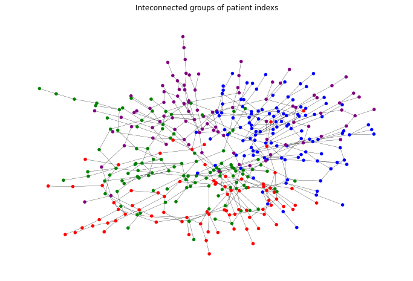

```python
draw_clu(subg, pos_copy, partitions_copy)
```

### Explainations:

# 8 Centrality Metrics:

- Medicine Attending_indegree: Count of incoming connections to the Medicine Attending.
- Medicine Attending_outdegree: Count of outgoing connections from the Medicine Attending.

```python
required_feats = ["patient_index","Encounter_index","Medicine Attending_indegree",
                  "Medicine Attending_outdegree","Medicine Attending_betweeness",
                  "Nurse_indegree", "Nurse_outdegree",
                 "O:E",  "hour_of_discharge"]

centrality_data = data[required_feats]
centrality_data.isna().sum()
```

```
patient_index                     0
Encounter_index                   0
Medicine Attending_indegree      33
Medicine Attending_outdegree     33
Medicine Attending_betweeness    33
Nurse_indegree                    0
Nurse_outdegree                   0
O:E                               0
hour_of_discharge                 0
dtype: int64
```

```python
centrality_data = centrality_data.dropna().reset_index(drop=True)
```

```python
centrality_data.loc[:,"hour_of_discharge"] = centrality_data["hour_of_discharge"].astype(int)
centrality_data.loc[:,"O:E"] = centrality_data["O:E"].astype(int)
centrality_data.loc[:,"Medicine Attending_indegree"] = centrality_data["Medicine Attending_indegree"].astype(int)
centrality_data.loc[:,"Medicine Attending_outdegree"] = centrality_data["Medicine Attending_outdegree"].astype(int)
centrality_data.loc[:,"patient_index"] = centrality_data["patient_index"].astype(int)
centrality_data.loc[:,"Encounter_index"] = centrality_data["Encounter_index"].astype(int)
centrality_data.loc[:,"Nurse_indegree"] = centrality_data["Nurse_indegree"].astype(int)
centrality_data.loc[:,"Nurse_outdegree"] = centrality_data["Nurse_outdegree"].astype(int)
```

#### Cleaned centrality data

```python
centrality_data.head()
```

[output not shown]

### 8.1) Impact of medicine attenging indegree

### 8.2) Impact of medicine attenging Outdegree

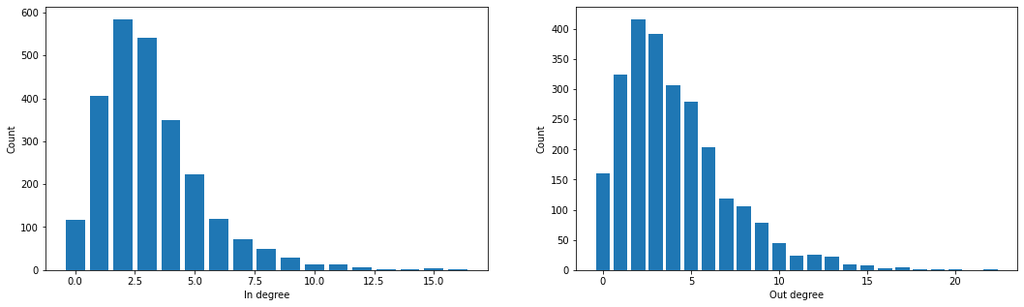

```python
fig, ax = plt.subplots(1,2 , figsize = (18,5))

indegree_count= dict(Counter(centrality_data["Medicine Attending_indegree"]))
outdegree_count= dict(Counter(centrality_data["Medicine Attending_outdegree"]))


ax[0].bar(indegree_count.keys(), indegree_count.values())
ax[1].bar(outdegree_count.keys(), outdegree_count.values())


ax[0].set_xlabel("In degree")
ax[0].set_ylabel("Count")

ax[1].set_xlabel("Out degree")
ax[1].set_ylabel("Count")

plt.show()
```

### explainations:

The indegree plot illustrates the number of incoming connections to the Medicine Attending. Notably, there's a substantial concentration of patient indexes associated with an indegree value of 2. This suggests that a large portion of patient IDs receive relatively fewer incoming connections from Medicine Attending, while only a select few patient indexes receive a high volume of incoming connections from Medicine Attending.

### 8.3) Impact of Nurse indegree and Nurse outdegree on O:E

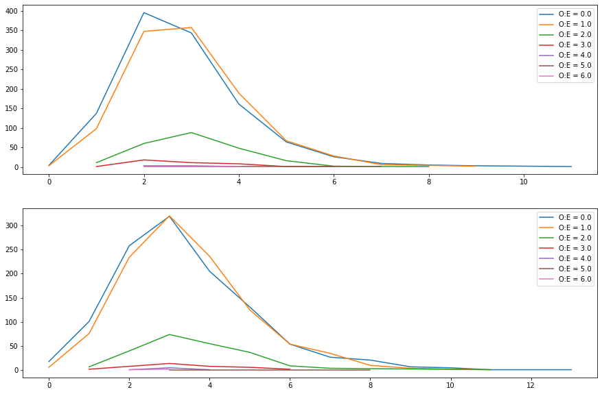

```python
fig,ax = plt.subplots(2,1, figsize=(15, 10))
oe = set(centrality_data["O:E"])

for val in oe:
    filterd =centrality_data[centrality_data["O:E"] == val]
    group =filterd.groupby("Nurse_indegree")["O:E"].count()
    ax[0].plot(group, label = f"O:E = {val}" )

ax[0].legend()

hod = set(centrality_data["O:E"])
for val in hod:
    filterd =centrality_data[centrality_data["O:E"] == val]
    group =filterd.groupby("Nurse_outdegree")["O:E"].count()
    ax[1].plot(group, label = f"O:E = {val}" )

ax[1].legend()
plt.show()
```